# Les tournois du Grand Chelem au Tennis

Hordan Romain

04/11/2021

```r
library(tidyverse)
library(broom)
```

**Importation des données de Github**

```r
player_dob <- readr::read_csv("https://raw.githubusercontent.com/rfordatascience/tidytuesday/master/data/2019/2019-04-09/player_dob.csv")
grand_slams <- readr::read_csv("https://raw.githubusercontent.com/rfordatascience/tidytuesday/master/data/2019/2019-04-09/grand_slams.csv")
grand_slam_timeline <- readr::read_csv("https://raw.githubusercontent.com/rfordatascience/tidytuesday/master/data/2019/2019-04-09/grand_slam_timeline.csv")
```

**Renommer les variables de chaque table :**

```r
detailsJoueur = rename(player_dob, joueur=name, grand_chelem=grand_slam, dateNaissance=date_of_birth, date_1er_Titre=date_of_first_title)

grand_slams = rename(grand_slams, année=year, grand_chelem=grand_slam, joueur=name, victoireCumulé=rolling_win_count, dateTournoi=tournament_date, genre=gender)

historique_GC = rename(grand_slam_timeline, joueur=player, année=year, grand_chelem=tournament, résultat=outcome, genre=gender)
```

```r
q1 = detailsJoueur %>%
  summarise(detailsJoueur, age_année = age/365)

age_moyen = mean(detailsJoueur$age/365,na.rm = TRUE)
age_moyen
```

```
## [1] 23.37207
```

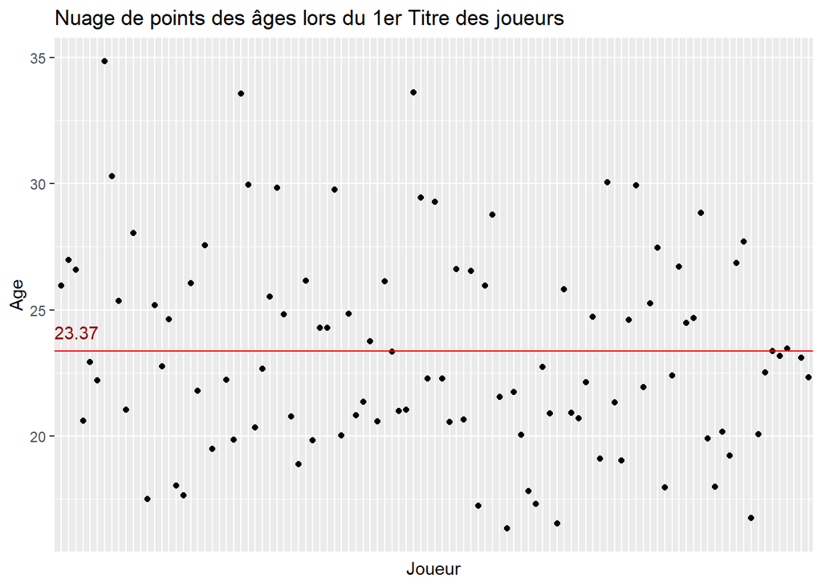

```r
q1 %>% ggplot(aes(x=joueur,y=age_année))+
  geom_point(na.rm = T)+
  geom_hline(yintercept = age_moyen,color = "red")+ xlab("Joueur")+ylab("Age")+
  annotate(geom = "text", label = round(age_moyen,2), x = 0, y = age_moyen+0.75, hjust = 0, color="darkred")+ theme(axis.text.x = element_blank(), axis.ticks.x =element_blank())+labs(title = "Nuage de points des âges lors du 1er Titre des joueurs")
```

**Question 2 : Dans quel grand chelem est réparti leur première victoire ?**

**On modifie les données erronnées.**

```r
detailsJoueur$grand_chelem[detailsJoueur$grand_chelem=="Australian Open (Jan.)"]="Australian Open"

detailsJoueur$grand_chelem[detailsJoueur$grand_chelem=="Australian Open (January)"]="Australian Open"

detailsJoueur$grand_chelem[detailsJoueur$grand_chelem=="Australian Open (December)"]="Australian Open"
```

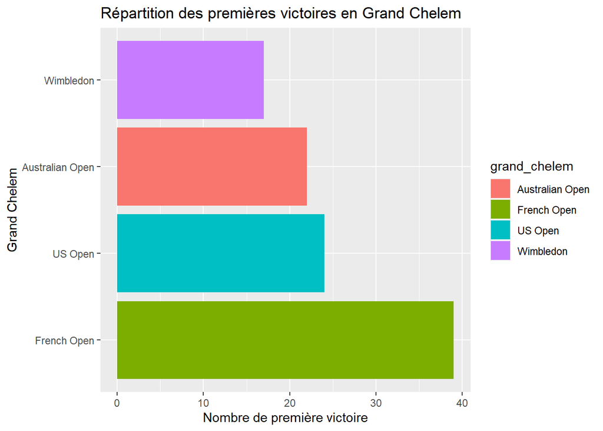

```r
q2= detailsJoueur %>% drop_na() %>% group_by(grand_chelem) %>% summarise(N=n())

q2 %>% ggplot(aes(x= reorder(grand_chelem, -N),y= N,fill=grand_chelem)) + geom_col()+coord_flip()+xlab("Grand Chelem")+ylab("Nombre de première victoire")+labs(title = "Répartition des premières victoires en Grand Chelem")
```

**Question 3 : Comment est réparti le palmarès en grand chelem des joueurs selon leur genre en fonction des années ?**

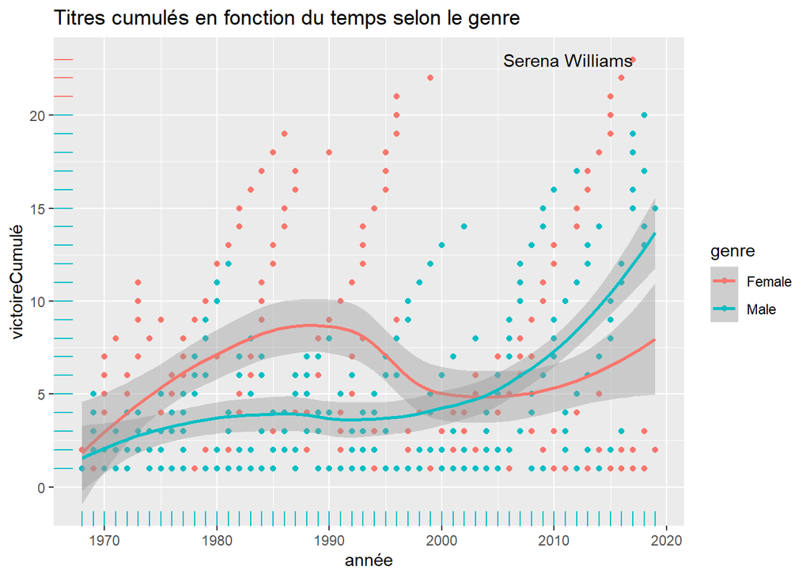

```r
q3= grand_slams %>% drop_na()

q3 %>% ggplot(aes(x=année,y =victoireCumulé,color=genre))+geom_point()+geom_rug() +geom_smooth(method = "loess",formula = "y ~ x") + annotate(geom = "text", label = "Serena Williams", x = 2017, y = 23, hjust = 1)+labs(title = "Titres cumulés en fonction du temps selon le genre")
```

**Question 4 : Comment les titres des grands joueurs s’accumulent en fonction de leur âge selon leur genre ?**

```r
q4 = left_join(grand_slams, detailsJoueur, by = c("joueur")) %>%
  mutate(age = as.numeric(dateTournoi - dateNaissance)/365) %>%
  group_by(joueur, age, genre) %>%
  summarise(counts = n()) %>%
  group_by(joueur) %>%
  mutate(victoireCumulé = cumsum(counts)) %>%
  arrange(desc(victoireCumulé))
```

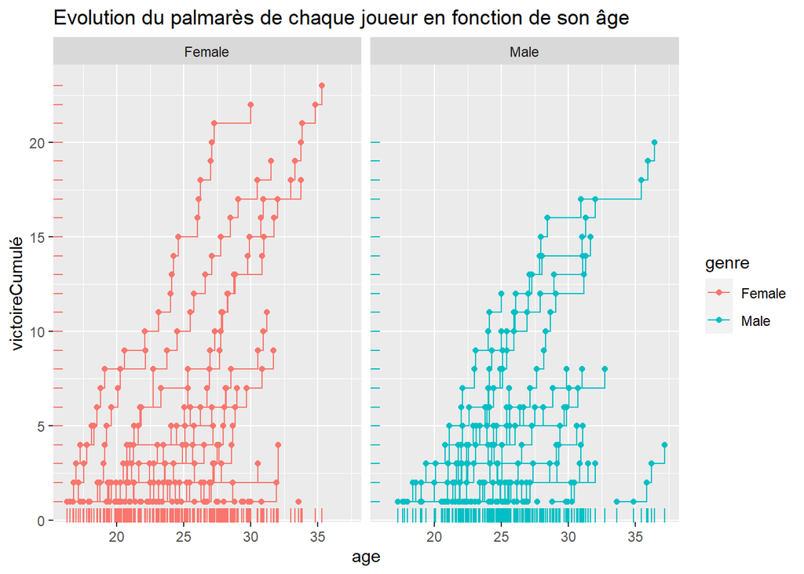

```r
q4 %>% ggplot(aes(x = age, y = victoireCumulé, group = joueur,color=genre)) + geom_point() + geom_step()+geom_rug() + facet_wrap(~genre)+labs(title = "Evolution du palmarès de chaque joueur en fonction de son âge")
```

**Question 5 : En se penchant sur Roland Garros, quelle est la performance de ces quatre joueurs sélectionnés sur terre battue pendant leur carrière ?**

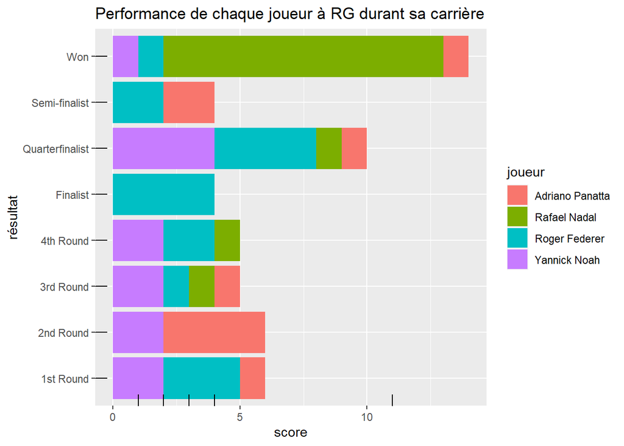

```r
# top_n(.,10,wt =  score)
q5 = historique_GC %>%
    filter(grand_chelem=="French Open",
           résultat != "Absent" & résultat != "Retired",joueur%in%c("Yannick Noah","Adriano Panatta","Rafael Nadal","Roger Federer")) %>%
  group_by(joueur,résultat) %>% summarise(score=n())
q5 %>% ggplot(aes(x = score,y =résultat,fill=joueur ))+geom_col()+geom_rug()+labs(title = "Performance de chaque joueur à RG durant sa carrière")
```

**Question 6 : Réaliser un test d’anova entre l’age de la première victoire et le lieu du succès**

```r
influence = anova(lm(detailsJoueur$age~detailsJoueur$grand_chelem))
influence
```

```
## Analysis of Variance Table
##
## Response: detailsJoueur$age
##                            Df    Sum Sq Mean Sq F value Pr(>F)
## detailsJoueur$grand_chelem  3   3176006 1058669  0.4828  0.695
## Residuals                  98 214881940 2192673
```

Le test d’anova n’est pas significatif car la Fisher value du test est faible et inférieur au Fisher théorique, et la pvalue vaut 0.695 ce qui est très élevé. Ainsi, l’âge de la première victoire n’est pas influencé par le lieu où s’est produit cette performance.

**Question 7 : Analyse graphique pour confirmation du test d’anova :**

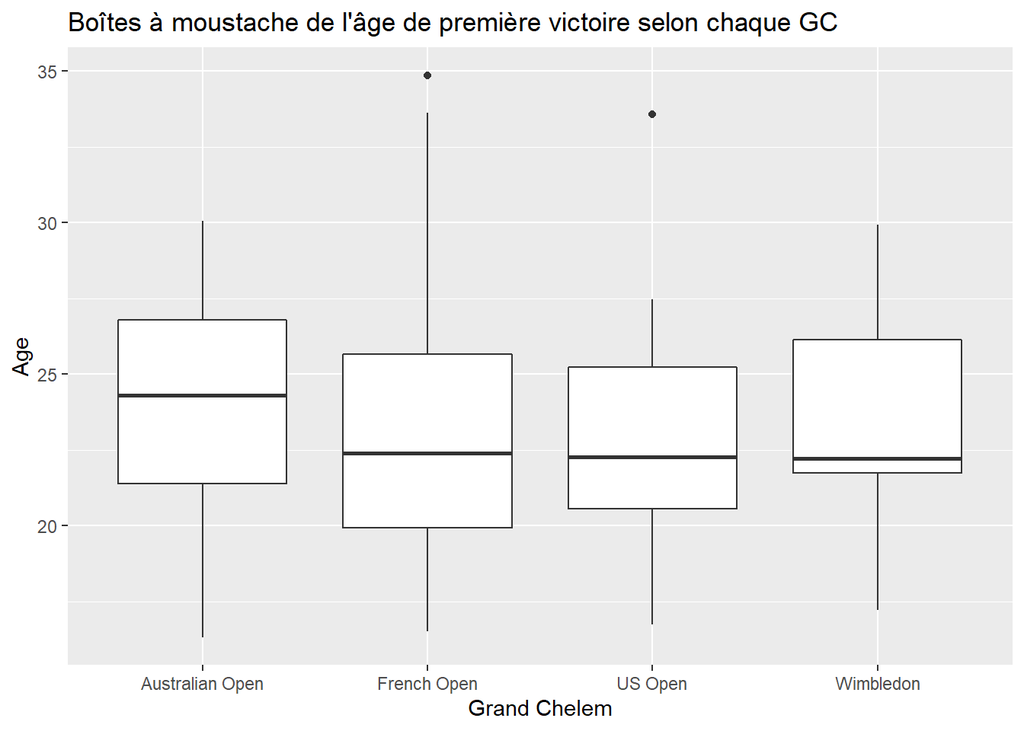

```r
detailsJoueur %>% drop_na() %>%  ggplot(aes(x=grand_chelem,y=age/365))+geom_boxplot(na.rm = T)+labs(title = "Boîtes à moustache de l'âge de première victoire selon chaque GC")+xlab("Grand Chelem")+ylab("Age")
```

**Question 8 : Quels sont les meilleurs joueurs et joueuses de tout les temps à avoir gagné AU MOINS 10 Grands Chelems ?**

```r
q8 = grand_slams %>%
  count(joueur, grand_chelem, sort = T) %>% # n
  add_count(joueur, wt=n) %>% # nn
  filter(nn >=10) %>%
  mutate(joueur = fct_reorder(joueur,n, sum)) # réorganiser par sum totale
```

```
## Storing counts in `nn`, as `n` already present in input
## i Use `name = "new_name"` to pick a new name.
```

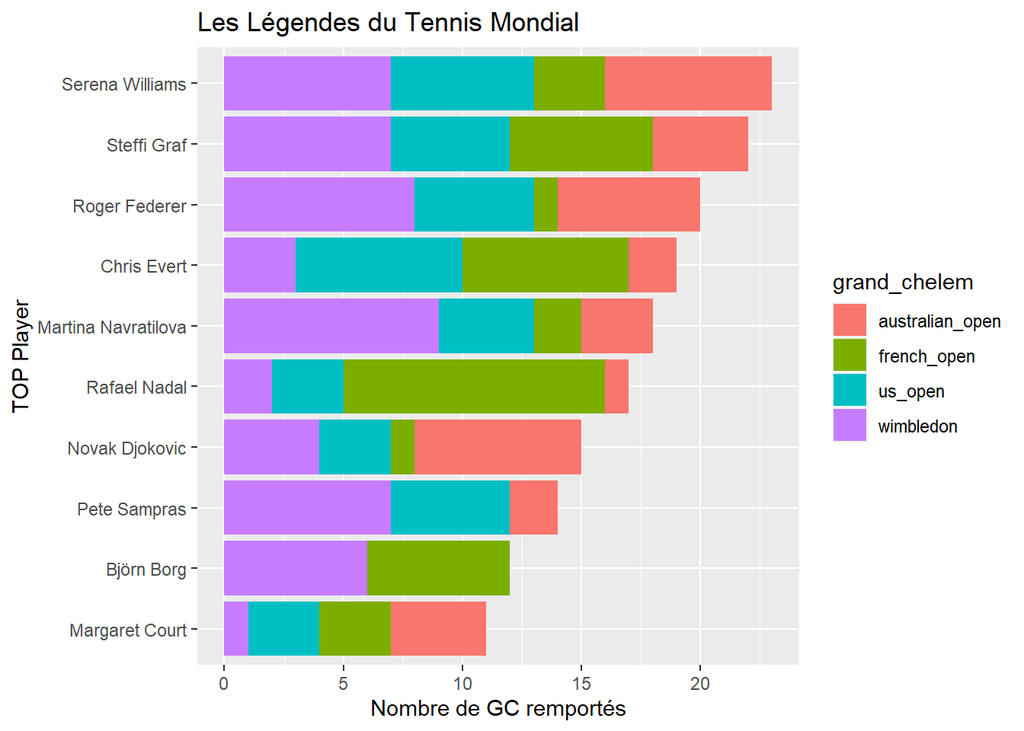

```r
 q8 %>% ggplot(aes(x=joueur, y=n,fill=grand_chelem))+geom_col()+coord_flip()+ylab("Nombre de GC remportés")+xlab("TOP Player")+labs(title = "Les Légendes du Tennis Mondial")
```